# Practical Machine Learning Project : Prediction Assignment

madhav

May 1, 2017

## Background of data

Using devices such as Jawbone Up, Nike FuelBand, and Fitbit it is now possible to collect a large amount of data about personal activity relatively inexpensively. These type of devices are part of the quantified self movement - a group of enthusiasts who take measurements about themselves regularly to improve their health, to find patterns in their behavior, or because they are tech geeks. One thing that people regularly do is quantify how much of a particular activity they do, but they rarely quantify how well they do it. In this project, your goal will be to use data from accelerometers on the belt, forearm, arm, and dumbell of 6 participants. They were asked to perform barbell lifts correctly and incorrectly in 5 different ways. More information is available from the website here: http://groupware.les.inf.puc-rio.br/har (see the section on the Weight Lifting Exercise Dataset).

## sources of Data

The training data for this project are available here:

https://d396qusza40orc.cloudfront.net/predmachlearn/pml-training.csv

The test data are available here:

https://d396qusza40orc.cloudfront.net/predmachlearn/pml-testing.csv

The data for this project come from this source: http://groupware.les.inf.puc-rio.br/har. If you use the document you create for this class for any purpose please cite them as they have been very generous in allowing their data to be used for this kind of assignment.

## What you should submit

The goal of your project is to predict the manner in which they did the exercise. This is the “classe” variable in the training set. You may use any of the other variables to predict with. You should create a report describing **how you built your model, how you used cross validation, what you think the expected out of sample error is**, and why you made the choices you did. You will also use your prediction model to predict 20 different test cases.

### loading data:

we can donload data using the chunk below

```r
#training data
download.file(url = "https://d396qusza40orc.cloudfront.net/predmachlearn/pml-training.csv", destfile = "./pml-training.csv", method = "curl")
#testing data
download.file(url = "https://d396qusza40orc.cloudfront.net/predmachlearn/pml-testing.csv", destfile = "./pml-testing.csv", method = "curl")
```

as i have already downloaded the data,i will now load them.use “na.strings” to ensure that miscellaneous NA, #DIV/0! and empty fields are represented as NA.

```r
setwd("E:\\course era\\practical Ml\\w4")#setting directory
train<-read.csv("pml-training.csv",na.strings=c("NA","#DIV/0!",""))
test<-read.csv("pml-testing.csv",na.strings=c("NA","#DIV/0!",""))
dim(train)
```

```
## [1] 19622   160
```

```r
dim(test)#can check the number of features given
```

```
## [1]  20 160
```

```r
str(train, list.len=20)
```

```
## 'data.frame':    19622 obs. of  160 variables:
##  $ X                       : int  1 2 3 4 5 6 7 8 9 10 ...
##  $ user_name               : Factor w/ 6 levels "adelmo","carlitos",..: 2 2 2 2 2 2 2 2 2 2 ...
##  $ raw_timestamp_part_1    : int  1323084231 1323084231 1323084231 1323084232 1323084232 1323084232 1323084232 1323084232 1323084232 1323084232 ...
##  $ raw_timestamp_part_2    : int  788290 808298 820366 120339 196328 304277 368296 440390 484323 484434 ...
##  $ cvtd_timestamp          : Factor w/ 20 levels "02/12/2011 13:32",..: 9 9 9 9 9 9 9 9 9 9 ...
##  $ new_window              : Factor w/ 2 levels "no","yes": 1 1 1 1 1 1 1 1 1 1 ...
##  $ num_window              : int  11 11 11 12 12 12 12 12 12 12 ...
##  $ roll_belt               : num  1.41 1.41 1.42 1.48 1.48 1.45 1.42 1.42 1.43 1.45 ...
##  $ pitch_belt              : num  8.07 8.07 8.07 8.05 8.07 8.06 8.09 8.13 8.16 8.17 ...
##  $ yaw_belt                : num  -94.4 -94.4 -94.4 -94.4 -94.4 -94.4 -94.4 -94.4 -94.4 -94.4 ...
##  $ total_accel_belt        : int  3 3 3 3 3 3 3 3 3 3 ...
##  $ kurtosis_roll_belt      : num  NA NA NA NA NA NA NA NA NA NA ...
##  $ kurtosis_picth_belt     : num  NA NA NA NA NA NA NA NA NA NA ...
##  $ kurtosis_yaw_belt       : logi  NA NA NA NA NA NA ...
##  $ skewness_roll_belt      : num  NA NA NA NA NA NA NA NA NA NA ...
##  $ skewness_roll_belt.1    : num  NA NA NA NA NA NA NA NA NA NA ...
##  $ skewness_yaw_belt       : logi  NA NA NA NA NA NA ...
##  $ max_roll_belt           : num  NA NA NA NA NA NA NA NA NA NA ...
##  $ max_picth_belt          : int  NA NA NA NA NA NA NA NA NA NA ...
##  $ max_yaw_belt            : num  NA NA NA NA NA NA NA NA NA NA ...
##   [list output truncated]
```

```r
table(is.na(train))#gives number of NA in complete data.
```

```
##
##   FALSE    TRUE
## 1214418 1925102
```

```r
table(is.na(train$classe))
```

```
##
## FALSE
## 19622
```

from the above we are clear that there are many NA in the data, and even first six of the features/independent variables given are not that useful in model building so we can discard them.

```r
train <- train[, 7:160]#removing unwanted coloumns.
test  <- test[, 7:160]
```

## we are here removing the coloumns that have more number of NA(based on observations in “classe”)

```r
out_data  <- apply(!is.na(train), 2, sum) > 19621  # which is the number of observations
train <- train[, out_data]
test  <- test[, out_data]
dim(train)
```

```
## [1] 19622    54
```

```r
dim(test)#can check the number of features given
```

```
## [1] 20 54
```

## Partitioning the Dataset

here we split the train in the ratio 60:40,so that we can perform training and cross validation,evaluation respectively.we can estimate the sample error by doing so.

```r
set.seed(3141592)
library(caret)
```

```r
library(ggplot2)
inTrain <- createDataPartition(y=train$classe, p=0.60, list=FALSE)
train1  <- train[inTrain,]
train2  <- train[-inTrain,]
dim(train1)
```

```
## [1] 11776    54
```

```r
dim(train2)
```

```
## [1] 7846   54
```

we can see that train1:-11776x54,train2:-7846x54.we check here for near zero covariates and discard them.

```r
nzv_cols <- nearZeroVar(train1)
if(length(nzv_cols) > 0) {
  train1 <- train1[, -nzv_cols]
  train2 <- train2[, -nzv_cols]
}
dim(train1)
```

```
## [1] 11776    54
```

```r
dim(train2)
```

```
## [1] 7846   54
```

as observed no near zero covariates were seen maybe due to our data cleaning done on features with NA’S.we are now ready to build a model.before that we will be checking the most important of all features.

```r
library(randomForest)
```

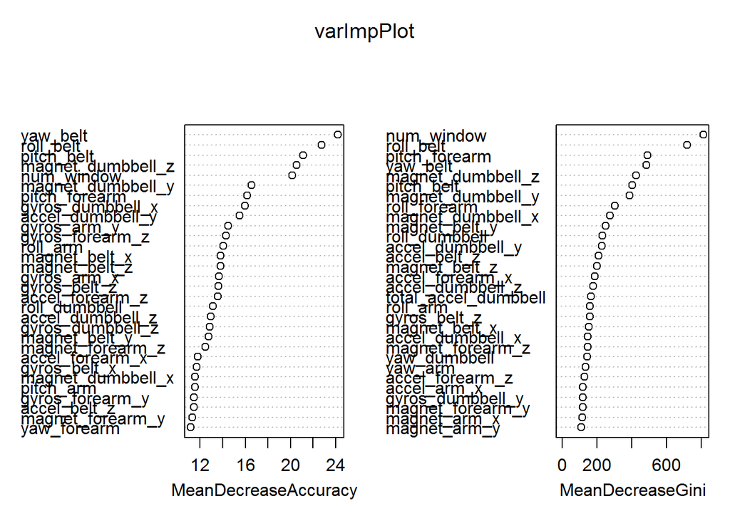

```r
## randomForest 4.6-10
## Type rfNews() to see new features/changes/bug fixes.
set.seed(3141592)
fitModel <- randomForest(classe~., data=train1, importance=TRUE, ntree=100)
varImpPlot(fitModel,main = "varImpPlot")
```

```r
imp<-importance(fitModel)
imp_f<-imp[,7]>200#here i have selected top features using gini index.here 200 is                   #being picked up randomly
imp_f_names<-imp_f[imp_f=="TRUE"]
imp_f_names_names<-names(imp_f_names)
```

now we will check for corelations between these feature that have gini value>200.

```r
corrmatrix = cor(train1[,imp_f_names_names])
library(arm)
```

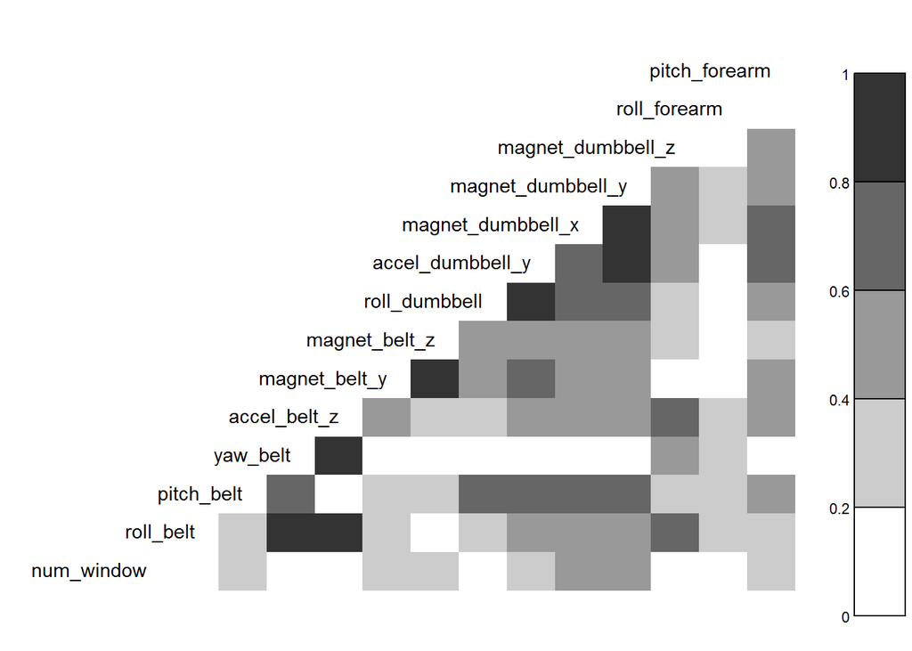

```r
corrplot(corrmatrix)#we can see the corelated features in the plot.
```

```r
diag(corrmatrix) <- 0
which(abs(corrmatrix)>0.75, arr.ind=TRUE)#co related features with value more than 0.75.
```

```
##                   row col
## yaw_belt            4   2
## accel_belt_z        5   2
## roll_belt           2   4
## accel_belt_z        5   4
## roll_belt           2   5
## yaw_belt            4   5
## magnet_belt_z       7   6
## magnet_belt_y       6   7
## magnet_dumbbell_y  11  10
## magnet_dumbbell_x  10  11
```

```r
which(abs(corrmatrix)>0.90, arr.ind=TRUE)#co related features with value more than 0.90.
```

```
##              row col
## accel_belt_z   5   2
## roll_belt      2   5
```

by observing above result it is clear that yaw_belt&roll_belt, accel_belt_z&roll_belt, accel_belt_z&yaw_belt, magnet_belt_z&magnet_belt_y, magnet_dumbbell_y&magnet_dumbbell_x are corelated.

if we observe the varImpPlot we can clearly see that yaw_belt&roll_belt show high priority,here should apply pca analysis for the corelated feature but iam going on without applying pca.so we can discard “accel_belt_z” as it has corelation with both,magnet_belt_z,magnet_dumbbell_x are to be discarded.for ease yaw_belt has been discarded.

```r
train1<-train1[,-which(names(train1) %in% c("accel_belt_z","magnet_belt_z","magnet_dumbbell_x","yaw_belt"))]
```

## Building the Decision Tree Model

we will first build decision tree model

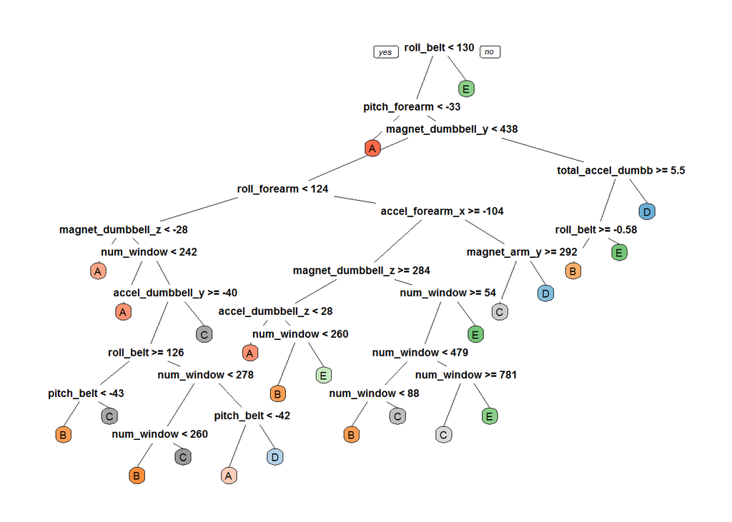

```r
library(rpart)
library(rpart.plot)
dtModel <- rpart(classe~., data=train1, method="class")
prp(dtModel, box.palette="auto")#plot of decision tree,we can see that the first feature selected is rollbelt, this reiterates its importance in the data.
```

```r
set.seed(12345)
prediction <- predict(dtModel, newdata = train2, type = "class")
caret::confusionMatrix(prediction, train2$classe)
```

```
## Confusion Matrix and Statistics
##
##           Reference
## Prediction    A    B    C    D    E
##          A 2023  352   49  143   88
##          B   58  799   48   28   62
##          C   14  169 1179  130   35
##          D  130  183   92  913  197
##          E    7   15    0   72 1060
##
## Overall Statistics
##
##                Accuracy : 0.7614
##                  95% CI : (0.7518, 0.7708)
##     No Information Rate : 0.2845
##     P-Value [Acc > NIR] : < 2.2e-16
##
##                   Kappa : 0.6967
##  Mcnemar's Test P-Value : < 2.2e-16
##
## Statistics by Class:
##
##                      Class: A Class: B Class: C Class: D Class: E
## Sensitivity            0.9064   0.5264   0.8618   0.7100   0.7351
## Specificity            0.8874   0.9690   0.9463   0.9082   0.9853
## Pos Pred Value         0.7620   0.8030   0.7721   0.6026   0.9185
## Neg Pred Value         0.9597   0.8951   0.9701   0.9411   0.9429
## Prevalence             0.2845   0.1935   0.1744   0.1639   0.1838
## Detection Rate         0.2578   0.1018   0.1503   0.1164   0.1351
## Detection Prevalence   0.3384   0.1268   0.1946   0.1931   0.1471
## Balanced Accuracy      0.8969   0.7477   0.9041   0.8091   0.8602
```

## out of sample error estimation

```r
sum(prediction!= train2$classe) / length(train2$classe)
```

```
## [1] 0.2385929
```

## Building the Random forest model

we will now build the random forest model on the same data on which we built decision tree.

```r
set.seed(12345)
modFitRF <- randomForest(classe ~ ., data = train1, ntree = 1000)
```

```r
prediction <- predict(modFitRF, newdata = train2, type = "class")
confusionMatrix(prediction, train2$classe)
```

```
## Confusion Matrix and Statistics
##
##           Reference
## Prediction    A    B    C    D    E
##          A 2231    1    0    0    0
##          B    1 1514    4    0    0
##          C    0    3 1364   13    0
##          D    0    0    0 1270    0
##          E    0    0    0    3 1442
##
## Overall Statistics
##
##                Accuracy : 0.9968
##                  95% CI : (0.9953, 0.9979)
##     No Information Rate : 0.2845
##     P-Value [Acc > NIR] : < 2.2e-16
##
##                   Kappa : 0.996
##  Mcnemar's Test P-Value : NA
##
## Statistics by Class:
##
##                      Class: A Class: B Class: C Class: D Class: E
## Sensitivity            0.9996   0.9974   0.9971   0.9876   1.0000
## Specificity            0.9998   0.9992   0.9975   1.0000   0.9995
## Pos Pred Value         0.9996   0.9967   0.9884   1.0000   0.9979
## Neg Pred Value         0.9998   0.9994   0.9994   0.9976   1.0000
## Prevalence             0.2845   0.1935   0.1744   0.1639   0.1838
## Detection Rate         0.2843   0.1930   0.1738   0.1619   0.1838
## Detection Prevalence   0.2845   0.1936   0.1759   0.1619   0.1842
## Balanced Accuracy      0.9997   0.9983   0.9973   0.9938   0.9998
```

## out of sample error estimation

```r
sum(prediction!= train2$classe) / length(train2$classe)
```

```
## [1] 0.003186337
```

## Predicting on the Testing Data (pml-testing.csv)

```r
DTprediction <- predict(dtModel,test , type = "class")
DTprediction
```

```
##  1  2  3  4  5  6  7  8  9 10 11 12 13 14 15 16 17 18 19 20
##  C  A  C  A  A  E  D  D  A  A  C  C  B  A  E  D  A  A  A  B
## Levels: A B C D E
```

### Prediction on random forest

```r
rfprediction <- predict(modFitRF,test , type = "class")
rfprediction
```

```
##  1  2  3  4  5  6  7  8  9 10 11 12 13 14 15 16 17 18 19 20
##  B  A  B  A  A  E  D  B  A  A  B  C  B  A  E  E  A  B  B  B
## Levels: A B C D E
```

# Submission file

By comparing we found Random Forest model is very accurate, about 99%. Because of that we could expect nearly all of the submitted test cases to be correct.

Prepare the submission file.

```r
pml_write_files = function(x){
  n = length(x)
  for(i in 1:n){
    filename = paste0("problem_id_",i,".txt")
    write.table(x[i],file=filename,quote=FALSE,row.names=FALSE,col.names=FALSE)
  }
}

pml_write_files(rfprediction)
```

## conclusion

here we have built decision tree model and random forest model on the given data, and have got about 99% accuracy in random forest model.while refering this donot over look the assumptions made.